# SHRS Market Analysis — BLS Projections 2022–2032

SHRS MQE Capstone Team

2026-02-13

# 0 — Setup & Data Loading

## 0.1 Packages

```r
library(tidyverse)
library(scales)
library(knitr)
library(kableExtra)
```

## 0.2 SOC Crosswalk — All 9 SHRS Programs

```r
soc_crosswalk <- tribble(
  ~shrs_program, ~shrs_dept,  ~soc_code,  ~occupation_title,
  "SLP",         "CSD",       "29-1127",  "Speech-Language Pathologists",
  "AuD",         "CSD",       "29-1181",  "Audiologists",
  "HIM",         "HIM",       "29-9021",  "Health Information Technologists and Medical Registrars",
  "OTD",         "RST",       "29-1122",  "Occupational Therapists",
  "DPT",         "RST",       "29-1123",  "Physical Therapists",
  "PAS",         "PAS",       "29-1071",  "Physician Assistants",
  "AT",          "SMN",       "29-9091",  "Athletic Trainers",
  "DN",          "SMN",       "29-1031",  "Dietitians and Nutritionists",
  "SS",          "SMN",       "29-1128",  "Exercise Physiologists"
)

target_socs <- soc_crosswalk$soc_code
```

## 0.3 Load the 2022–2032 Projections Data

```r
# ── EDIT THIS PATH to match your machine ──
PROJ_CSV_PATH <- file.path(path.expand("~"), "Documents", "SHRS_Analysis",
                            "market_analysis", "v3data", "projections_csv",
                            "occupation_csv", "occupation_2022.csv")

raw_2022 <- read_csv(PROJ_CSV_PATH, show_col_types = FALSE)

# Standardize column names (same 14-column structure)
names(raw_2022) <- c(
  "occ_title", "soc_code", "occ_type",
  "emp_2022", "emp_2032",
  "emp_change_num", "emp_change_pct",
  "lf_exit_rate", "occ_transfer_rate", "total_sep_rate",
  "lf_exits", "occ_transfers", "total_separations",
  "annual_openings"
)

# Clean numeric fields
raw_2022 <- raw_2022 |>
  mutate(across(c(emp_2022:annual_openings), ~ {
    x <- str_remove_all(as.character(.x), ",")
    x <- na_if(x, "—")
    x <- na_if(x, "--")
    as.numeric(x)
  }))
```

## 0.4 Extract Benchmarks & SHRS Subset

```r
all_occ <- raw_2022 |> filter(soc_code == "00-0000")
all_occ_growth_pct   <- all_occ$emp_change_pct
all_occ_sep_rate     <- all_occ$total_sep_rate
all_occ_openings     <- all_occ$annual_openings

cat("All-Occupations benchmark (2022-2032):\n")
```

```
## All-Occupations benchmark (2022-2032):
```

```r
cat("  Growth:", all_occ_growth_pct, "%\n")
```

```
##   Growth: 2.8 %
```

```r
cat("  Sep rate:", all_occ_sep_rate, "%\n")
```

```
##   Sep rate: 10.9 %
```

```r
cat("  Annual openings:", comma(all_occ_openings * 1000), "\n")
```

```
##   Annual openings: 18,566,500
```

```r
proj_2022 <- raw_2022 |>
  filter(soc_code %in% target_socs, occ_type == "Line item") |>
  left_join(soc_crosswalk, by = "soc_code") |>
  select(shrs_program, shrs_dept, soc_code, occ_title = occupation_title,
         emp_base = emp_2022, emp_projected = emp_2032,
         emp_change_num, emp_change_pct,
         lf_exit_rate, occ_transfer_rate, total_sep_rate,
         lf_exits, occ_transfers, total_separations, annual_openings) |>
  arrange(shrs_dept, shrs_program)

cat("\nSHRS programs loaded:", nrow(proj_2022), "of 9 expected\n")
```

```
##
## SHRS programs loaded: 9 of 9 expected
```

```r
cat("Programs found:", paste(proj_2022$shrs_program, collapse = ", "), "\n")
```

```
## Programs found: AuD, SLP, HIM, PAS, DPT, OTD, AT, DN, SS
```

# 1 — Employment Growth Analysis

## 1.1 Projected Growth Rates vs Benchmark

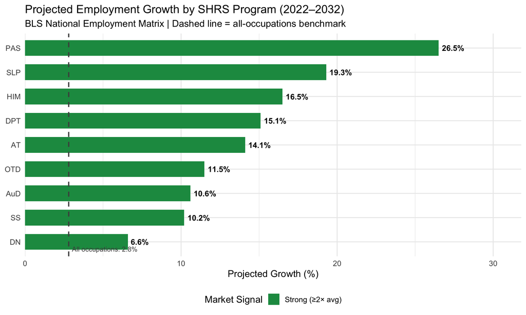

```r
proj_2022 |>
  mutate(
    health = case_when(
      emp_change_pct >= all_occ_growth_pct * 2 ~ "Strong (≥2× avg)",
      emp_change_pct >= all_occ_growth_pct     ~ "Healthy (≥ avg)",
      emp_change_pct >= 0                       ~ "Caution (below avg)",
      TRUE                                      ~ "Declining"
    ),
    health = factor(health, levels = c("Strong (≥2× avg)", "Healthy (≥ avg)",
                                        "Caution (below avg)", "Declining"))
  ) |>
  ggplot(aes(x = reorder(shrs_program, emp_change_pct), y = emp_change_pct,
             fill = health)) +
  geom_col(width = 0.65) +
  geom_hline(yintercept = all_occ_growth_pct, linetype = "dashed",
             color = "gray30", linewidth = 0.8) +
  geom_text(aes(label = paste0(emp_change_pct, "%")),
            hjust = -0.15, size = 3.8, fontface = "bold") +
  coord_flip() +
  scale_fill_manual(values = c(
    "Strong (≥2× avg)"   = "#1a9850",
    "Healthy (≥ avg)"     = "#91cf60",
    "Caution (below avg)" = "#fee08b",
    "Declining"           = "#d73027"
  )) +
  scale_y_continuous(expand = expansion(mult = c(0, 0.2))) +
  annotate("text", x = 0.5, y = all_occ_growth_pct,
           label = paste0("All occupations: ", all_occ_growth_pct, "%"),
           hjust = -0.05, vjust = -0.5, size = 3.3, color = "gray30") +
  labs(
    title    = "Projected Employment Growth by SHRS Program (2022–2032)",
    subtitle = "BLS National Employment Matrix | Dashed line = all-occupations benchmark",
    x = NULL, y = "Projected Growth (%)", fill = "Market Signal"
  ) +
  theme_minimal(base_size = 13) +
  theme(legend.position = "bottom")
```

## 1.2 Employment Levels — Base vs Projected

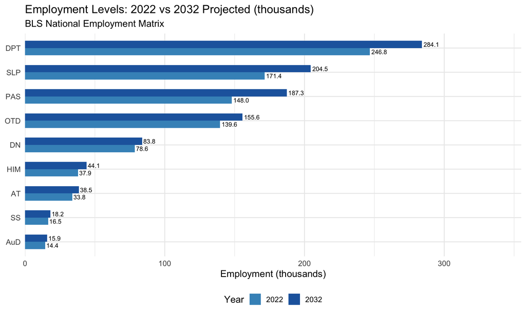

```r
proj_2022 |>
  select(shrs_program, emp_base, emp_projected) |>
  pivot_longer(cols = c(emp_base, emp_projected), names_to = "period",
               values_to = "employment") |>
  mutate(period = if_else(period == "emp_base", "2022", "2032")) |>
  ggplot(aes(x = reorder(shrs_program, employment), y = employment,
             fill = period)) +
  geom_col(position = "dodge", width = 0.6) +
  geom_text(aes(label = comma(employment, accuracy = 0.1)),
            position = position_dodge(width = 0.6), hjust = -0.1, size = 3) +
  coord_flip() +
  scale_fill_manual(values = c("2022" = "#4393c3", "2032" = "#2166ac")) +
  scale_y_continuous(labels = comma, expand = expansion(mult = c(0, 0.25))) +
  labs(
    title    = "Employment Levels: 2022 vs 2032 Projected (thousands)",
    subtitle = "BLS National Employment Matrix",
    x = NULL, y = "Employment (thousands)", fill = "Year"
  ) +
  theme_minimal(base_size = 13) +
  theme(legend.position = "bottom")
```

## 1.3 Growth Summary Table

```r
proj_2022 |>
  mutate(
    vs_benchmark_pp = round(emp_change_pct - all_occ_growth_pct, 1),
    growth_signal = case_when(
      emp_change_pct >= all_occ_growth_pct * 2 ~ "🟢 Strong",
      emp_change_pct >= all_occ_growth_pct     ~ "🟢 Healthy",
      emp_change_pct >= 0                       ~ "🟡 Caution",
      TRUE                                      ~ "🔴 Declining"
    )
  ) |>
  select(
    Program       = shrs_program,
    Dept          = shrs_dept,
    `Emp Base (K)`  = emp_base,
    `Emp Proj (K)`  = emp_projected,
    `Change (K)`    = emp_change_num,
    `Growth (%)`    = emp_change_pct,
    `vs Bench (pp)` = vs_benchmark_pp,
    Signal        = growth_signal
  ) |>
  arrange(desc(`Growth (%)`)) |>
  kable(format.args = list(big.mark = ",")) |>
  kable_styling(bootstrap_options = c("striped", "hover"), full_width = FALSE)
```

| Program | Dept | Emp Base (K) | Emp Proj (K) | Change (K) | Growth (%) | vs Bench (pp) | Signal |
| --- | --- | --- | --- | --- | --- | --- | --- |
| PAS | PAS | 148.0 | 187.3 | 39.3 | 26.5 | 23.7 | 🟢 Strong \| |
| SLP | CSD | 171.4 | 204.5 | 33.1 | 19.3 | 16.5 | 🟢 Strong \| |
| HIM | HIM | 37.9 | 44.1 | 6.2 | 16.5 | 13.7 | 🟢 Strong \| |
| DPT | RST | 246.8 | 284.1 | 37.3 | 15.1 | 12.3 | 🟢 Strong \| |
| AT | SMN | 33.8 | 38.5 | 4.8 | 14.1 | 11.3 | 🟢 Strong \| |
| OTD | RST | 139.6 | 155.6 | 16.1 | 11.5 | 8.7 | 🟢 Strong \| |
| AuD | CSD | 14.4 | 15.9 | 1.5 | 10.6 | 7.8 | 🟢 Strong \| |
| SS | SMN | 16.5 | 18.2 | 1.7 | 10.2 | 7.4 | 🟢 Strong \| |
| DN | SMN | 78.6 | 83.8 | 5.2 | 6.6 | 3.8 | 🟢 Strong \| |

# 2 — Job Openings & Replacement Demand

## 2.1 Components of Annual Openings

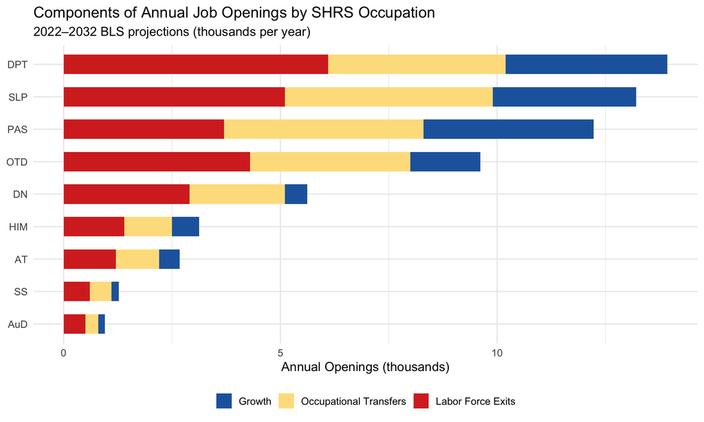

```r
proj_2022 |>
  mutate(growth_component = pmax(emp_change_num / 10, 0)) |>
  select(shrs_program, `Labor Force Exits` = lf_exits,
         `Occupational Transfers` = occ_transfers,
         `Growth` = growth_component) |>
  pivot_longer(-shrs_program, names_to = "component", values_to = "value") |>
  mutate(component = factor(component,
                             levels = c("Growth", "Occupational Transfers",
                                        "Labor Force Exits"))) |>
  ggplot(aes(x = reorder(shrs_program, value, sum), y = value,
             fill = component)) +
  geom_col(width = 0.6) +
  coord_flip() +
  scale_fill_manual(values = c(
    "Growth"                  = "#2166ac",
    "Occupational Transfers"  = "#fee08b",
    "Labor Force Exits"       = "#d73027"
  )) +
  labs(
    title    = "Components of Annual Job Openings by SHRS Occupation",
    subtitle = "2022–2032 BLS projections (thousands per year)",
    x = NULL, y = "Annual Openings (thousands)", fill = NULL
  ) +
  theme_minimal(base_size = 13) +
  theme(legend.position = "bottom")
```

## 2.2 Separation Rates vs Benchmark

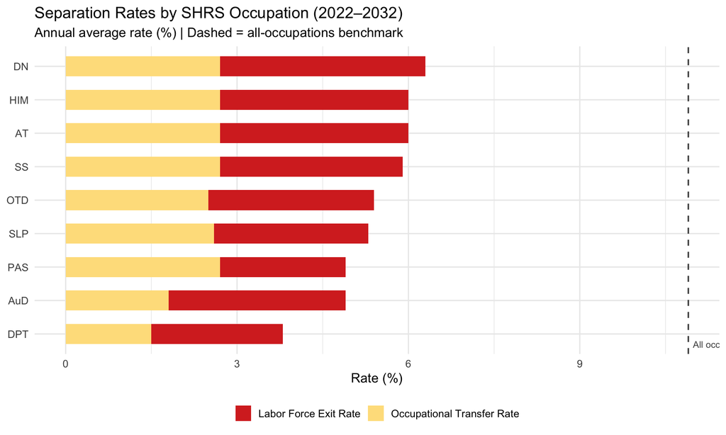

```r
proj_2022 |>
  select(shrs_program, lf_exit_rate, occ_transfer_rate) |>
  pivot_longer(-shrs_program, names_to = "type", values_to = "rate") |>
  mutate(type = if_else(type == "lf_exit_rate", "Labor Force Exit Rate",
                        "Occupational Transfer Rate")) |>
  ggplot(aes(x = reorder(shrs_program, rate, sum), y = rate, fill = type)) +
  geom_col(width = 0.6) +
  geom_hline(yintercept = all_occ_sep_rate, linetype = "dashed",
             color = "gray30", linewidth = 0.7) +
  coord_flip() +
  scale_fill_manual(values = c(
    "Labor Force Exit Rate"       = "#d73027",
    "Occupational Transfer Rate"  = "#fee08b"
  )) +
  annotate("text", x = 0.5, y = all_occ_sep_rate,
           label = paste0("All occ sep rate: ", all_occ_sep_rate, "%"),
           hjust = -0.05, vjust = -0.5, size = 3.2, color = "gray30") +
  labs(
    title    = "Separation Rates by SHRS Occupation (2022–2032)",
    subtitle = "Annual average rate (%) | Dashed = all-occupations benchmark",
    x = NULL, y = "Rate (%)", fill = NULL
  ) +
  theme_minimal(base_size = 13) +
  theme(legend.position = "bottom")
```

## 2.3 Openings & Separations Table

```r
proj_2022 |>
  mutate(
    openings_signal = case_when(
      annual_openings >= 10 ~ "🟢 High Volume",
      annual_openings >= 3  ~ "🟢 Solid",
      annual_openings >= 1  ~ "🟡 Moderate",
      TRUE                  ~ "🔴 Limited"
    ),
    replacement_signal = case_when(
      total_sep_rate >= 6 ~ "🟢 High Replacement",
      total_sep_rate >= 4 ~ "🟡 Moderate",
      TRUE                ~ "🔴 Low"
    )
  ) |>
  select(
    Program         = shrs_program,
    `Exit Rate (%)`     = lf_exit_rate,
    `Transfer Rate (%)` = occ_transfer_rate,
    `Total Sep Rate (%)` = total_sep_rate,
    `Openings/yr (K)`   = annual_openings,
    `Openings Signal`   = openings_signal,
    `Replacement Signal` = replacement_signal
  ) |>
  kable() |>
  kable_styling(bootstrap_options = c("striped", "hover"), full_width = FALSE)
```

| Program | Exit Rate (%) | Transfer Rate (%) | Total Sep Rate (%) | Openings/yr (K) | Openings Signal | Replacement Signal |
| --- | --- | --- | --- | --- | --- | --- |
| AuD | 3.1 | 1.8 | 4.9 | 0.9 | 🔴 Limited \| | Moderate \| |
| SLP | 2.7 | 2.6 | 5.3 | 13.2 | 🟢 High Volume \| | Moderate \| |
| HIM | 3.3 | 2.7 | 6.0 | 3.1 | 🟢 Solid \| | High Replacement \| |
| PAS | 2.2 | 2.7 | 4.9 | 12.2 | 🟢 High Volume \| | Moderate \| |
| DPT | 2.3 | 1.5 | 3.8 | 13.9 | 🟢 High Volume \| | Low \| |
| OTD | 2.9 | 2.5 | 5.4 | 9.6 | 🟢 Solid \| | Moderate \| |
| AT | 3.3 | 2.7 | 6.0 | 2.7 | 🟡 Moderate \| | High Replacement \| |
| DN | 3.6 | 2.7 | 6.3 | 5.6 | 🟢 Solid \| | High Replacement \| |
| SS | 3.2 | 2.7 | 5.9 | 1.2 | 🟡 Moderate \| | Moderate \| |

# 3 — Market Size & Scale Analysis

## 3.1 Size vs Growth Scatter

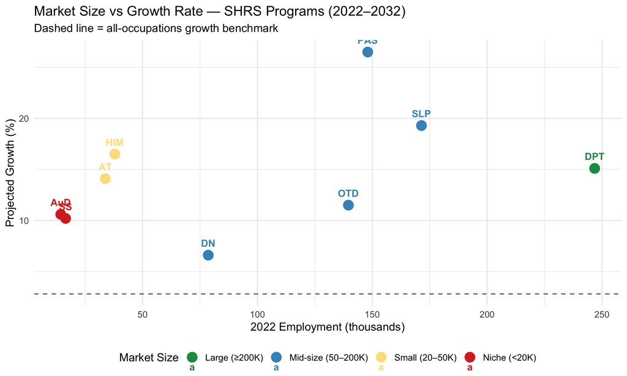

```r
proj_2022 |>
  mutate(
    market_size = case_when(
      emp_base >= 200 ~ "Large (≥200K)",
      emp_base >= 50  ~ "Mid-size (50–200K)",
      emp_base >= 20  ~ "Small (20–50K)",
      TRUE            ~ "Niche (<20K)"
    ),
    market_size = factor(market_size,
                          levels = c("Large (≥200K)", "Mid-size (50–200K)",
                                     "Small (20–50K)", "Niche (<20K)"))
  ) |>
  ggplot(aes(x = emp_base, y = emp_change_pct,
             color = market_size, label = shrs_program)) +
  geom_point(size = 5) +
  geom_text(vjust = -1.2, size = 4, fontface = "bold") +
  geom_hline(yintercept = all_occ_growth_pct, linetype = "dashed",
             color = "gray40") +
  scale_color_manual(values = c(
    "Large (≥200K)"      = "#1a9850",
    "Mid-size (50–200K)" = "#4393c3",
    "Small (20–50K)"     = "#fee08b",
    "Niche (<20K)"       = "#d73027"
  )) +
  scale_x_continuous(labels = comma) +
  labs(
    title    = "Market Size vs Growth Rate — SHRS Programs (2022–2032)",
    subtitle = "Dashed line = all-occupations growth benchmark",
    x = "2022 Employment (thousands)", y = "Projected Growth (%)",
    color = "Market Size"
  ) +
  theme_minimal(base_size = 13) +
  theme(legend.position = "bottom")
```

## 3.2 Openings Intensity

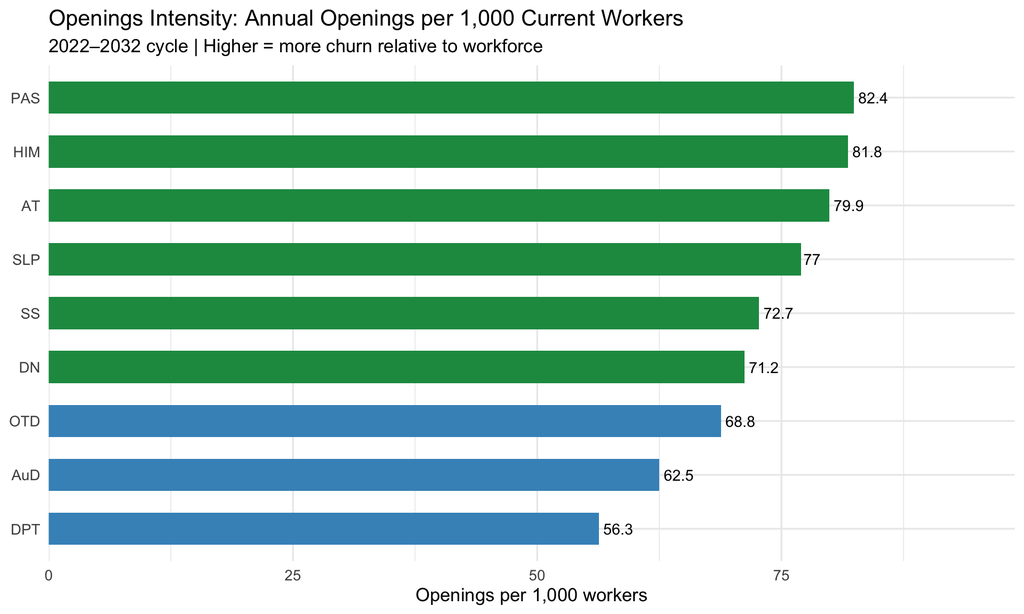

```r
proj_2022 |>
  mutate(openings_intensity = round(annual_openings / emp_base * 1000, 1)) |>
  ggplot(aes(x = reorder(shrs_program, openings_intensity),
             y = openings_intensity,
             fill = if_else(openings_intensity >= 70, "High", "Normal"))) +
  geom_col(width = 0.6) +
  geom_text(aes(label = openings_intensity), hjust = -0.15, size = 3.8) +
  coord_flip() +
  scale_fill_manual(values = c("High" = "#1a9850", "Normal" = "#4393c3"),
                     guide = "none") +
  scale_y_continuous(expand = expansion(mult = c(0, 0.2))) +
  labs(
    title    = "Openings Intensity: Annual Openings per 1,000 Current Workers",
    subtitle = "2022–2032 cycle | Higher = more churn relative to workforce",
    x = NULL, y = "Openings per 1,000 workers"
  ) +
  theme_minimal(base_size = 13)
```

# 4 — Program-Level Scorecard (0–100 Scale)

```r
rescale_0_100 <- function(x) {
  rng <- range(x, na.rm = TRUE)
  if (rng[2] == rng[1]) return(rep(50, length(x)))
  round((x - rng[1]) / (rng[2] - rng[1]) * 100, 1)
}

scorecard_2022 <- proj_2022 |>
  mutate(
    growth_score     = rescale_0_100(emp_change_pct),
    openings_score   = rescale_0_100(annual_openings),
    sep_rate_score   = rescale_0_100(total_sep_rate),
    emp_scale_score  = rescale_0_100(emp_base),

    composite_score  = round((growth_score + openings_score +
                               sep_rate_score + emp_scale_score) / 4, 1),

    health_signal = case_when(
      composite_score >= 65 ~ "Green",
      composite_score >= 40 ~ "Yellow",
      TRUE                  ~ "Red"
    ),
    health_signal = factor(health_signal, levels = c("Green", "Yellow", "Red"))
  )
```

## 4.1 Scorecard Heatmap

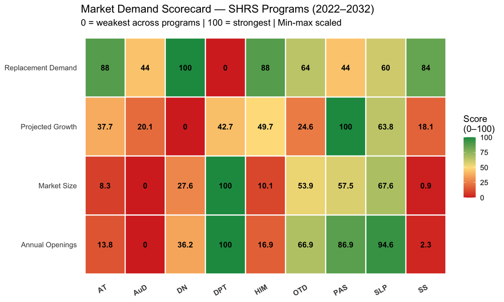

```r
scorecard_2022 |>
  select(shrs_program, growth_score, openings_score,
         sep_rate_score, emp_scale_score) |>
  pivot_longer(-shrs_program, names_to = "dimension", values_to = "score") |>
  mutate(dimension = case_when(
    dimension == "growth_score"    ~ "Projected Growth",
    dimension == "openings_score"  ~ "Annual Openings",
    dimension == "sep_rate_score"  ~ "Replacement Demand",
    dimension == "emp_scale_score" ~ "Market Size"
  )) |>
  ggplot(aes(x = shrs_program, y = dimension, fill = score)) +
  geom_tile(color = "white", linewidth = 0.8) +
  geom_text(aes(label = score), size = 4, fontface = "bold") +
  scale_fill_gradient2(low = "#d73027", mid = "#fee08b", high = "#1a9850",
                        midpoint = 50, limits = c(0, 100),
                        name = "Score\n(0–100)") +
  labs(
    title    = "Market Demand Scorecard — SHRS Programs (2022–2032)",
    subtitle = "0 = weakest across programs | 100 = strongest | Min-max scaled",
    x = NULL, y = NULL
  ) +
  theme_minimal(base_size = 13) +
  theme(axis.text.x = element_text(face = "bold", angle = 30, hjust = 1),
        panel.grid = element_blank())
```

## 4.2 Composite Score Bar Chart

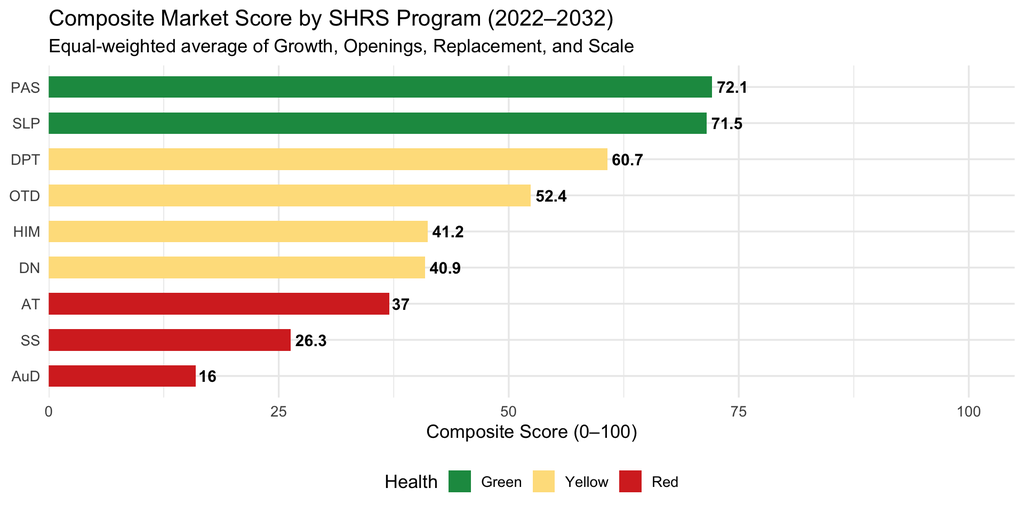

```r
scorecard_2022 |>
  ggplot(aes(x = reorder(shrs_program, composite_score), y = composite_score,
             fill = health_signal)) +
  geom_col(width = 0.6) +
  geom_text(aes(label = composite_score), hjust = -0.15, size = 4,
            fontface = "bold") +
  coord_flip() +
  scale_fill_manual(values = c(
    "Green"  = "#1a9850",
    "Yellow" = "#fee08b",
    "Red"    = "#d73027"
  )) +
  scale_y_continuous(limits = c(0, 105), expand = expansion(mult = c(0, 0))) +
  labs(
    title    = "Composite Market Score by SHRS Program (2022–2032)",
    subtitle = "Equal-weighted average of Growth, Openings, Replacement, and Scale",
    x = NULL, y = "Composite Score (0–100)", fill = "Health"
  ) +
  theme_minimal(base_size = 13) +
  theme(legend.position = "bottom")
```

## 4.3 Full Scorecard Table

```r
scorecard_2022 |>
  select(
    Program          = shrs_program,
    Dept             = shrs_dept,
    `Growth (%)`     = emp_change_pct,
    `Openings/yr (K)` = annual_openings,
    `Sep Rate (%)`   = total_sep_rate,
    `Emp Base (K)`   = emp_base,
    `Growth Sc`      = growth_score,
    `Open Sc`        = openings_score,
    `Sep Sc`         = sep_rate_score,
    `Scale Sc`       = emp_scale_score,
    `Composite`      = composite_score,
    Signal           = health_signal
  ) |>
  arrange(desc(Composite)) |>
  kable(format.args = list(big.mark = ",")) |>
  kable_styling(bootstrap_options = c("striped", "hover"), full_width = FALSE)
```

| Program | Dept | Growth (%) | Openings/yr (K) | Sep Rate (%) | Emp Base (K) | Growth Sc | Open Sc | Sep Sc | Scale Sc | Composite | Signal |
| --- | --- | --- | --- | --- | --- | --- | --- | --- | --- | --- | --- |
| PAS | PAS | 26.5 | 12.2 | 4.9 | 148.0 | 100.0 | 86.9 | 44 | 57.5 | 72.1 | Green |
| SLP | CSD | 19.3 | 13.2 | 5.3 | 171.4 | 63.8 | 94.6 | 60 | 67.6 | 71.5 | Green |
| DPT | RST | 15.1 | 13.9 | 3.8 | 246.8 | 42.7 | 100.0 | 0 | 100.0 | 60.7 | Yellow |
| OTD | RST | 11.5 | 9.6 | 5.4 | 139.6 | 24.6 | 66.9 | 64 | 53.9 | 52.4 | Yellow |
| HIM | HIM | 16.5 | 3.1 | 6.0 | 37.9 | 49.7 | 16.9 | 88 | 10.1 | 41.2 | Yellow |
| DN | SMN | 6.6 | 5.6 | 6.3 | 78.6 | 0.0 | 36.2 | 100 | 27.6 | 40.9 | Yellow |
| AT | SMN | 14.1 | 2.7 | 6.0 | 33.8 | 37.7 | 13.8 | 88 | 8.3 | 37.0 | Red |
| SS | SMN | 10.2 | 1.2 | 5.9 | 16.5 | 18.1 | 2.3 | 84 | 0.9 | 26.3 | Red |
| AuD | CSD | 10.6 | 0.9 | 4.9 | 14.4 | 20.1 | 0.0 | 44 | 0.0 | 16.0 | Red |

# 5 — Cross-Cycle Comparison: 2022 vs 2023 vs 2024

This section provides a preliminary view of how BLS projections have shifted across the three most recent cycles. This enables trend detection — are the BLS outlook revisions getting better or worse for each program?

> **Note:** For this section to render, you must first run the 2023 and 2024 analysis files to create `proj_2023_data` and `proj_2024_data` in your environment. If those objects don’t exist, this section will be skipped.

```r
has_other_cycles <- exists("proj_2023_data") & exists("proj_2024_data")

if (!has_other_cycles) {
  cat("⚠ proj_2023_data and/or proj_2024_data not found in environment.\n")
  cat("  Run the 2023 and 2024 analysis files first for cross-cycle comparison.\n")
  cat("  Skipping cross-cycle section.\n")
}
```

```
## ⚠ proj_2023_data and/or proj_2024_data not found in environment.
##   Run the 2023 and 2024 analysis files first for cross-cycle comparison.
##   Skipping cross-cycle section.
```

```r
# Build cross-cycle dataframe
cross_cycle <- bind_rows(
  proj_2022 |> mutate(cycle = "2022-2032"),
  proj_2023_data |> mutate(cycle = "2023-2033"),
  proj_2024_data |>
    rename(emp_base = emp_2024, emp_projected = emp_2034) |>
    mutate(cycle = "2024-2034")
) |>
  select(cycle, shrs_program, emp_change_pct, annual_openings,
         total_sep_rate, emp_base)
```

```r
cross_cycle |>
  ggplot(aes(x = cycle, y = emp_change_pct, group = shrs_program,
             color = shrs_program)) +
  geom_line(linewidth = 1.1) +
  geom_point(size = 3) +
  facet_wrap(~ shrs_program, ncol = 3, scales = "free_y") +
  labs(
    title    = "Growth Rate Across BLS Projection Cycles by SHRS Program",
    subtitle = "Tracking how the BLS outlook has evolved over 3 consecutive cycles",
    x = "Projection Cycle", y = "Projected Growth (%)"
  ) +
  theme_minimal(base_size = 12) +
  theme(legend.position = "none",
        axis.text.x = element_text(angle = 45, hjust = 1))
```

```r
cross_cycle |>
  select(cycle, shrs_program, emp_change_pct) |>
  pivot_wider(names_from = cycle, values_from = emp_change_pct) |>
  mutate(
    trend = case_when(
      `2024-2034` > `2023-2033` & `2023-2033` > `2022-2032` ~ "🟢 Improving",
      `2024-2034` < `2023-2033` & `2023-2033` < `2022-2032` ~ "🔴 Declining",
      TRUE ~ "🟡 Mixed"
    )
  ) |>
  rename(Program = shrs_program) |>
  kable() |>
  kable_styling(bootstrap_options = c("striped", "hover"), full_width = FALSE)
```

# 6 — Key Statistical Summaries

```r
cat("=== 2022-2032 Projection Cycle: Descriptive Statistics ===\n\n")
```

```
## === 2022-2032 Projection Cycle: Descriptive Statistics ===
```

```r
cat("Growth Rate (%):\n")
```

```
## Growth Rate (%):
```

```r
cat("  Mean:", round(mean(proj_2022$emp_change_pct), 2), "\n")
```

```
##   Mean: 14.49
```

```r
cat("  Median:", round(median(proj_2022$emp_change_pct), 2), "\n")
```

```
##   Median: 14.1
```

```r
cat("  SD:", round(sd(proj_2022$emp_change_pct), 2), "\n")
```

```
##   SD: 5.88
```

```r
cat("  Range:", min(proj_2022$emp_change_pct), "to",
    max(proj_2022$emp_change_pct), "\n\n")
```

```
##   Range: 6.6 to 26.5
```

```r
cat("Annual Openings (thousands):\n")
```

```
## Annual Openings (thousands):
```

```r
cat("  Mean:", round(mean(proj_2022$annual_openings), 2), "\n")
```

```
##   Mean: 6.93
```

```r
cat("  Median:", round(median(proj_2022$annual_openings), 2), "\n")
```

```
##   Median: 5.6
```

```r
cat("  Total:", round(sum(proj_2022$annual_openings), 2), "\n\n")
```

```
##   Total: 62.4
```

```r
cat("Separation Rate (%):\n")
```

```
## Separation Rate (%):
```

```r
cat("  Mean:", round(mean(proj_2022$total_sep_rate), 2), "\n")
```

```
##   Mean: 5.39
```

```r
cat("  Range:", min(proj_2022$total_sep_rate), "to",
    max(proj_2022$total_sep_rate), "\n\n")
```

```
##   Range: 3.8 to 6.3
```

```r
above <- sum(proj_2022$emp_change_pct >= all_occ_growth_pct)
below <- sum(proj_2022$emp_change_pct < all_occ_growth_pct)
cat("Programs above all-occ benchmark:", above, "of 9\n")
```

```
## Programs above all-occ benchmark: 9 of 9
```

```r
cat("Programs below all-occ benchmark:", below, "of 9\n")
```

```
## Programs below all-occ benchmark: 0 of 9
```

## 6.1 Correlations

```r
cor_growth_openings <- cor(proj_2022$emp_change_pct, proj_2022$annual_openings,
                            use = "complete.obs")
cor_growth_sep <- cor(proj_2022$emp_change_pct, proj_2022$total_sep_rate,
                       use = "complete.obs")

cat("Correlation (Growth % ↔ Annual Openings):", round(cor_growth_openings, 3), "\n")
```

```
## Correlation (Growth % ↔ Annual Openings): 0.568
```

```r
cat("Correlation (Growth % ↔ Sep Rate):", round(cor_growth_sep, 3), "\n")
```

```
## Correlation (Growth % ↔ Sep Rate): -0.377
```

# 7 — Stored Outputs for Downstream Modules

```r
# ─── PRIMARY DATA FRAMES ───
proj_2022_data <- proj_2022
scorecard_2022_data <- scorecard_2022

# ─── BENCHMARK VALUES ───
benchmark_2022 <- list(
  cycle             = "2022-2032",
  all_occ_growth    = all_occ_growth_pct,
  all_occ_sep_rate  = all_occ_sep_rate,
  all_occ_openings  = all_occ_openings
)

# ─── SUMMARY STATISTICS ───
summary_stats_2022 <- list(
  growth_mean     = round(mean(proj_2022$emp_change_pct), 2),
  growth_median   = round(median(proj_2022$emp_change_pct), 2),
  growth_sd       = round(sd(proj_2022$emp_change_pct), 2),
  openings_total  = round(sum(proj_2022$annual_openings), 2),
  openings_mean   = round(mean(proj_2022$annual_openings), 2),
  sep_rate_mean   = round(mean(proj_2022$total_sep_rate), 2),
  n_above_bench   = sum(proj_2022$emp_change_pct >= all_occ_growth_pct),
  n_below_bench   = sum(proj_2022$emp_change_pct < all_occ_growth_pct),
  cor_growth_open = round(cor_growth_openings, 3),
  cor_growth_sep  = round(cor_growth_sep, 3)
)

# ─── PROGRAM-LEVEL SIGNALS ───
program_signals_2022 <- scorecard_2022 |>
  select(shrs_program, shrs_dept, composite_score, health_signal,
         emp_change_pct, annual_openings, total_sep_rate, emp_base)

# ─── CROSS-CYCLE DATA (if available) ───
if (has_other_cycles) {
  cross_cycle_data <- cross_cycle
  cat("  cross_cycle_data       — ", nrow(cross_cycle_data), "rows (3 cycles × 9 programs)\n")
}

# ─── CROSSWALK (reusable) ───
soc_crosswalk_9 <- soc_crosswalk

# ─── PRINT CONFIRMATION ───
cat("=== Stored Objects for Downstream Use (2022-2032 Cycle) ===\n\n")
```

```
## === Stored Objects for Downstream Use (2022-2032 Cycle) ===
```

```r
cat("Data Frames:\n")
```

```
## Data Frames:
```

```r
cat("  proj_2022_data         — ", nrow(proj_2022_data), "rows × ",
    ncol(proj_2022_data), "cols\n")
```

```
##   proj_2022_data         —  9 rows ×  15 cols
```

```r
cat("  scorecard_2022_data    — ", nrow(scorecard_2022_data), "rows × ",
    ncol(scorecard_2022_data), "cols\n")
```

```
##   scorecard_2022_data    —  9 rows ×  21 cols
```

```r
cat("  program_signals_2022   — ", nrow(program_signals_2022), "rows\n\n")
```

```
##   program_signals_2022   —  9 rows
```

```r
cat("Lists:\n")
```

```
## Lists:
```

```r
cat("  benchmark_2022         — all-occ growth:",
    benchmark_2022$all_occ_growth, "%\n")
```

```
##   benchmark_2022         — all-occ growth: 2.8 %
```

```r
cat("  summary_stats_2022     — SHRS avg growth:",
    summary_stats_2022$growth_mean, "%\n\n")
```

```
##   summary_stats_2022     — SHRS avg growth: 14.49 %
```

```r
cat("Crosswalk:\n")
```

```
## Crosswalk:
```

```r
cat("  soc_crosswalk_9        — ", nrow(soc_crosswalk_9), "programs\n")
```

```
##   soc_crosswalk_9        —  9 programs
```

# Appendix: Data Source & Methodology

**Source:** Bureau of Labor Statistics, Employment Projections program — National Employment Matrix, 2022–2032 cycle (`occupation_2022.csv`)

**Variables used:**

| Column | Description | Unit |
| --- | --- | --- |
| `emp_base` (2022) | Base-year employment | Thousands |
| `emp_projected` (2032) | Projected employment | Thousands |
| `emp_change_pct` | Projected growth rate | Percent |
| `lf_exit_rate` | Labor force exit rate | Annual avg % |
| `occ_transfer_rate` | Occupational transfer rate | Annual avg % |
| `total_sep_rate` | Total separation rate | Annual avg % |
| `annual_openings` | Projected annual openings | Thousands/yr |

**Scorecard methodology:**

- Each of 4 dimensions (Growth, Openings, Replacement Demand, Market Size) is min-max scaled 0–100 across the 9 SHRS programs.
- Composite = simple average of the 4 dimension scores.
- Health signal: Green (≥65), Yellow (40–64), Red (<40).

**Cross-cycle comparison:** When all three cycle files are run in sequence (2024 → 2023 → 2022), the 2022 file builds a combined `cross_cycle_data` frame and visualizes trend direction (Improving / Mixed / Declining) for each program.

**All 9 programs covered:** SLP, AuD, HIM, OTD, DPT, PAS, AT, DN, SS